# Week 3: Logistic regression

First we read the packages and dataset done earlier

```r
library(dplyr)
library(tidyverse)
library(ggplot2)
library(GGally)
library(cowplot)
library(boot)

alc <- read.csv("~/IODS-project/data/alc.csv", header = T, sep = ",")

alc <- alc[,-1]
```

```r
dim(alc)
```

```
## [1] 382  35
```

```r
colnames(alc)
```

```
##  [1] "school"     "sex"        "age"        "address"    "famsize"
##  [6] "Pstatus"    "Medu"       "Fedu"       "Mjob"       "Fjob"
## [11] "reason"     "nursery"    "internet"   "guardian"   "traveltime"
## [16] "studytime"  "failures"   "schoolsup"  "famsup"     "paid"
## [21] "activities" "higher"     "romantic"   "famrel"     "freetime"
## [26] "goout"      "Dalc"       "Walc"       "health"     "absences"
## [31] "G1"         "G2"         "G3"         "alc_use"    "high_use"
```

We have 382 observations and 35 variables. The variables and observations are from two different datasets that can be accessed from: https://archive.ics.uci.edu/ml/machine-learning-databases/00320/

Meta text can be can accessed here: https://archive.ics.uci.edu/ml/datasets/Student+Performance

From the metatext: “This data approach student achievement in secondary education of two Portuguese schools. The data attributes include student grades, demographic, social and school related features) and it was collected by using school reports and questionnaires.”

We are going to study high/low alcohol consumption and its relationships to “extra-curricular activities”, “romantic relationship”, “quality of family relationships” (from 1 to 5) and “going out with friends” Next we take subset of the variables chosen:

```r
variables <- c("activities", "romantic", "famrel", "goout", "high_use")
new_alc <- select(alc,one_of(variables))
str(new_alc)
```

```
## 'data.frame':    382 obs. of  5 variables:
##  $ activities: Factor w/ 2 levels "no","yes": 1 1 1 2 1 2 1 1 1 2 ...
##  $ romantic  : Factor w/ 2 levels "no","yes": 1 1 1 2 1 1 1 1 1 1 ...
##  $ famrel    : int  4 5 4 3 4 5 4 4 4 5 ...
##  $ goout     : int  4 3 2 2 2 2 4 4 2 1 ...
##  $ high_use  : logi  FALSE FALSE TRUE FALSE FALSE FALSE ...
```

Hypothesis is that social activities and other social attributes correlate negatively with high use of alcohol. Or in other words we hypothise that better social life correlates with less alcohol consumption.

Next we plot the variables with the alcohol use

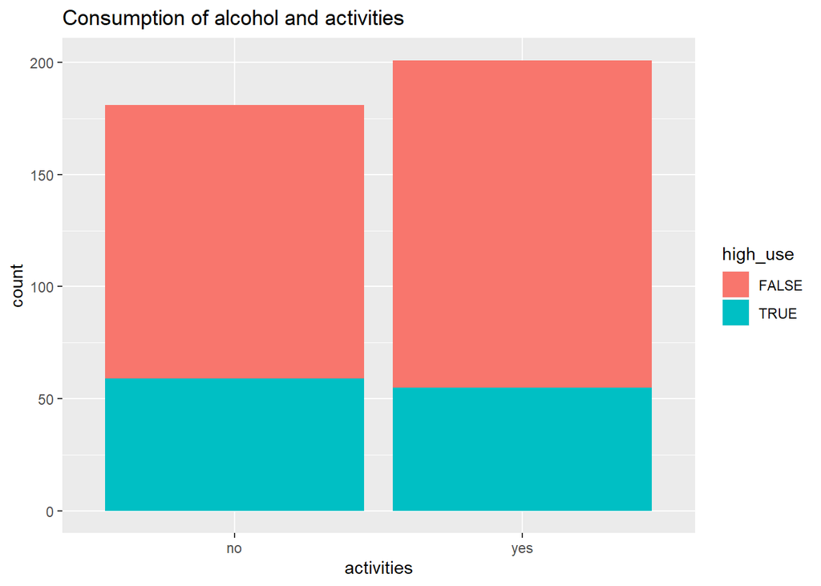

```r
alc_act <- ggplot(data = new_alc, aes(x = activities, fill = high_use)) + geom_bar() + ggtitle("Consumption of alcohol and activities")
alc_act
```

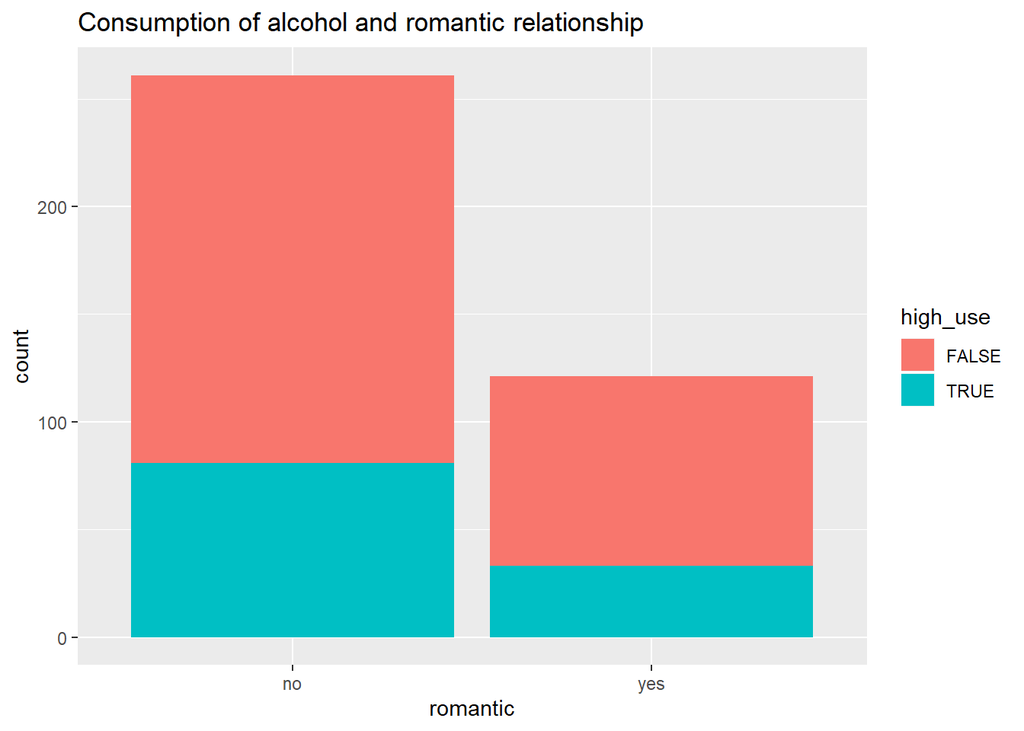

```r
alc_rom <- ggplot(data = new_alc, aes(x = romantic, fill = high_use)) + geom_bar() + ggtitle("Consumption of alcohol and romantic relationship")
alc_rom
```

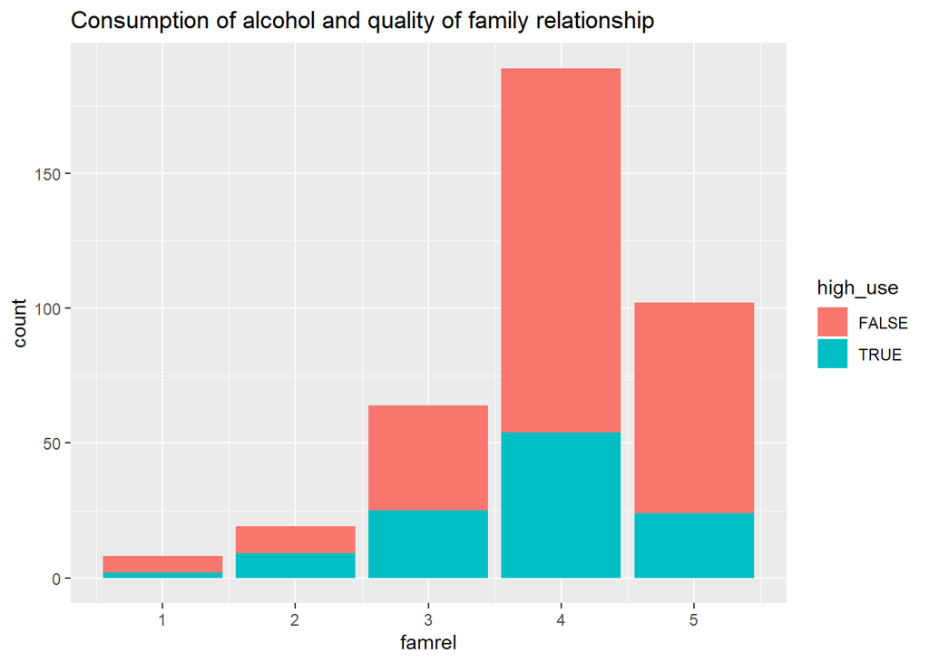

```r
alc_family <- ggplot(data = new_alc, aes(x = famrel, fill = high_use)) + geom_bar() + ggtitle("Consumption of alcohol and quality of family relationship")
alc_family
```

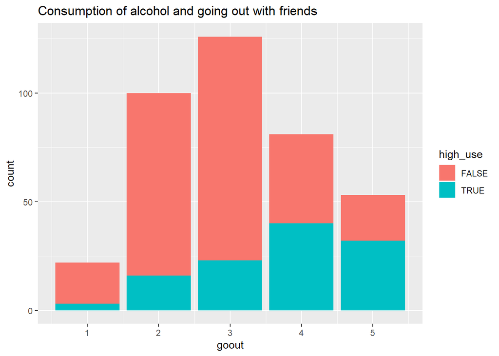

```r
alc_goout <- ggplot(data = new_alc, aes(x = goout, fill = high_use)) + geom_bar() + ggtitle("Consumption of alcohol and going out with friends")
alc_goout
```

Some findings from these plots: 1. Extra-curricular activities correlate with less alcohol consumptions (There is more observations for those who have activities but about same amount for high_use observations) 2. It looks like good family relations correlate with less alcohol consumptions. 3. People who go out with friends look like to be more probable to be high users of alcohol.

Next we take a look at the numbers:

```r
new_alc %>% group_by(activities,high_use) %>% summarise(count = n())
```

```
## # A tibble: 4 x 3
## # Groups:   activities [2]
##   activities high_use count
##   <fct>      <lgl>    <int>
## 1 no         FALSE      122
## 2 no         TRUE        59
## 3 yes        FALSE      146
## 4 yes        TRUE        55
```

1. Extra-curricular activities correlate with less alcohol consumptions

```r
new_alc %>% group_by(romantic,high_use) %>% summarise(count = n())
```

```
## # A tibble: 4 x 3
## # Groups:   romantic [2]
##   romantic high_use count
##   <fct>    <lgl>    <int>
## 1 no       FALSE      180
## 2 no       TRUE        81
## 3 yes      FALSE       88
## 4 yes      TRUE        33
```

2. Those who are not in a romantic relationship are more likely to be high users

```r
new_alc %>% group_by(famrel,high_use) %>% summarise(count = n())
```

```
## # A tibble: 10 x 3
## # Groups:   famrel [5]
##    famrel high_use count
##     <int> <lgl>    <int>
##  1      1 FALSE        6
##  2      1 TRUE         2
##  3      2 FALSE       10
##  4      2 TRUE         9
##  5      3 FALSE       39
##  6      3 TRUE        25
##  7      4 FALSE      135
##  8      4 TRUE        54
##  9      5 FALSE       78
## 10      5 TRUE        24
```

```r
new_alc %>% group_by(goout,high_use) %>% summarise(count = n())
```

```
## # A tibble: 10 x 3
## # Groups:   goout [5]
##    goout high_use count
##    <int> <lgl>    <int>
##  1     1 FALSE       19
##  2     1 TRUE         3
##  3     2 FALSE       84
##  4     2 TRUE        16
##  5     3 FALSE      103
##  6     3 TRUE        23
##  7     4 FALSE       41
##  8     4 TRUE        40
##  9     5 FALSE       21
## 10     5 TRUE        32
```

We make the same observations from the numbers than from the plots

We proceed to make the statistical model

```r
m1 <- glm(high_use ~ activities + romantic + famrel + goout, data = new_alc, family = "binomial")
```

Summary of the model

```r
summary(m1)
```

```
##
## Call:
## glm(formula = high_use ~ activities + romantic + famrel + goout,
##     family = "binomial", data = new_alc)
##
## Deviance Residuals:
##     Min       1Q   Median       3Q      Max
## -1.5238  -0.8258  -0.5829   1.0057   2.4929
##
## Coefficients:
##               Estimate Std. Error z value Pr(>|z|)
## (Intercept)    -1.8234     0.6269  -2.909  0.00363 **
## activitiesyes  -0.3035     0.2443  -1.242  0.21414
## romanticyes    -0.2690     0.2663  -1.010  0.31247
## famrel         -0.3671     0.1343  -2.733  0.00628 **
## goout           0.8027     0.1190   6.743 1.55e-11 ***
## ---
## Signif. codes:  0 '***' 0.001 '**' 0.01 '*' 0.05 '.' 0.1 ' ' 1
##
## (Dispersion parameter for binomial family taken to be 1)
##
##     Null deviance: 465.68  on 381  degrees of freedom
## Residual deviance: 405.44  on 377  degrees of freedom
## AIC: 415.44
##
## Number of Fisher Scoring iterations: 4
```

Only “quality of family relationships” and “going out with friends” are statistically significant. Let’s check if the model is better with only the significant variables.

```r
step(m1, direction = "backward")
```

```
## Start:  AIC=415.44
## high_use ~ activities + romantic + famrel + goout
##
##              Df Deviance    AIC
## - romantic    1   406.47 414.47
## - activities  1   406.98 414.98
## <none>            405.44 415.44
## - famrel      1   412.94 420.94
## - goout       1   459.20 467.20
##
## Step:  AIC=414.47
## high_use ~ activities + famrel + goout
##
##              Df Deviance    AIC
## - activities  1   408.12 414.12
## <none>            406.47 414.47
## - famrel      1   413.68 419.68
## - goout       1   459.94 465.94
##
## Step:  AIC=414.12
## high_use ~ famrel + goout
##
##          Df Deviance    AIC
## <none>        408.12 414.12
## - famrel  1   415.68 419.68
## - goout   1   460.92 464.92
```

```
##
## Call:  glm(formula = high_use ~ famrel + goout, family = "binomial",
##     data = new_alc)
##
## Coefficients:
## (Intercept)       famrel        goout
##     -2.0289      -0.3667       0.7922
##
## Degrees of Freedom: 381 Total (i.e. Null);  379 Residual
## Null Deviance:       465.7
## Residual Deviance: 408.1     AIC: 414.1
```

AIC is smallest with the model with only the significant variables, so we need to remove the others.

```r
m2 <- glm(high_use ~famrel + goout, data = new_alc, family = "binomial")
```

Summary of the model

```r
summary(m2)
```

```
##
## Call:
## glm(formula = high_use ~ famrel + goout, family = "binomial",
##     data = new_alc)
##
## Deviance Residuals:
##     Min       1Q   Median       3Q      Max
## -1.5448  -0.7518  -0.5252   0.9872   2.3530
##
## Coefficients:
##             Estimate Std. Error z value Pr(>|z|)
## (Intercept)  -2.0289     0.6148  -3.300 0.000966 ***
## famrel       -0.3667     0.1338  -2.740 0.006142 **
## goout         0.7922     0.1183   6.698 2.11e-11 ***
## ---
## Signif. codes:  0 '***' 0.001 '**' 0.01 '*' 0.05 '.' 0.1 ' ' 1
##
## (Dispersion parameter for binomial family taken to be 1)
##
##     Null deviance: 465.68  on 381  degrees of freedom
## Residual deviance: 408.12  on 379  degrees of freedom
## AIC: 414.12
##
## Number of Fisher Scoring iterations: 4
```

Coefficients of the model (all are statistically significant at 0.01 risk level)

```r
coef(m2)
```

```
## (Intercept)      famrel       goout
##  -2.0288785  -0.3666676   0.7921642
```

Odds ratios (OR)

```r
OR <- coef(m2) %>% exp
```

Confidence intervals (CI)

```r
CI <- confint(m2) %>% exp
```

Print out the odds ratios with their confidence intervals

```r
cbind(OR, CI)
```

```
##                    OR      2.5 %    97.5 %
## (Intercept) 0.1314829 0.03816207 0.4283774
## famrel      0.6930400 0.53161279 0.8999454
## goout       2.2081701 1.76229526 2.8045361
```

Our result is that one unit positive change in family relations means that you are 0.69 “more likely” to be a high drinker. Similarly one unit positive change in going out with friends means that you are 2.2 more likely to be a high drinker. Family relations supports our initial hypothesis.

Next we make predictions on the basis of our model

Prediction for the probability of high_use

```r
probabilities <- predict(m2, type = "response")

new_alc <- mutate(new_alc, probability = probabilities)
```

Using the probabilities to make a prediction of high_use

```r
new_alc <- mutate(new_alc, prediction = probability > 0.5)
```

Tabulate the target variable versus the predictions

```r
table(high_use = new_alc$high_use, prediction = new_alc$prediction)
```

```
##         prediction
## high_use FALSE TRUE
##    FALSE   243   25
##    TRUE     68   46
```

```r
table(high_use = new_alc$high_use, prediction = new_alc$prediction) %>% prop.table %>% addmargins()
```

```
##         prediction
## high_use      FALSE       TRUE        Sum
##    FALSE 0.63612565 0.06544503 0.70157068
##    TRUE  0.17801047 0.12041885 0.29842932
##    Sum   0.81413613 0.18586387 1.00000000
```

We can see from the table below that the model is predicting correctly High use 243+46 times (out of 243+68+25+46) and wrongly 68+25 times. Model predicts about 25 % of the times wrong -> less than simple guessing.

BONUS questions: 10-fold cross-validation

```r
loss_func <- function(class, prob) {
  n_wrong <- abs(class - prob) > 0.5
  mean(n_wrong)
}
```

Average number of wrong predictions in the (training) data

```r
loss_func(class = new_alc$high_use, prob = new_alc$probability)
```

```
## [1] 0.2434555
```

K-fold cross-validation

```r
library(boot)
cv <- cv.glm(data = new_alc, cost = loss_func, glmfit = m2, K = 10)
```

Average number of wrong predictions in the cross validation

```r
cv$delta[1]
```

```
## [1] 0.2591623
```

The model introduced has similar prediction rate compared to datacamp exercise (0.26)